# The entourage — five styles, the real cast

Every style below prints the owner's own entourage from the production export of 2026-10-15 (85 rows; 83 print — the couple are the masthead, not a line), built and named by the shipped `lib/entourage.ts` (prefix · first · middle · last · suffix, the group headings and the section order). **1–3 are screenshots of the real component** rendered in the Maker lab from `origin/rd/batch-8-event-hub`; **4–5 are drawings** on the same built groups. Full length everywhere — no "and 30 more". 21 Ninongs against 17 Ninangs is real: watch how each style carries the four who walk alone.

"show me the 5 styles we will present. use actual data of cale-ice … so i can see how they all look and pick which styles to keep" — owner, 15 Oct 2026

**1** Roll call **2** Two sides **3** The march **4** On the axis **5** Lines, singles centred Keep / drop

## 1 · shipped · ships tonight (#6541)Roll callreal render

Each group under its heading; a pair is two equal columns with no "&" (owner 2026-10-14), holding at 375; someone alone starts at the left edge; Parents and Immediate Family stack to one column on the phone with the role beside the name; Secondary Sponsors by role ("Candle"). The four solo Ninongs are four plain lines after the pairs.

375 × 812 · Chromium · the whole scene

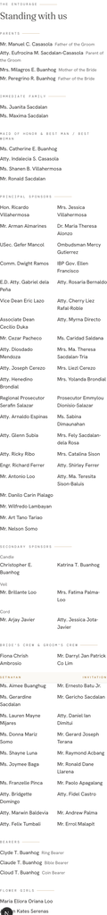

1280 × 800 · the reading column

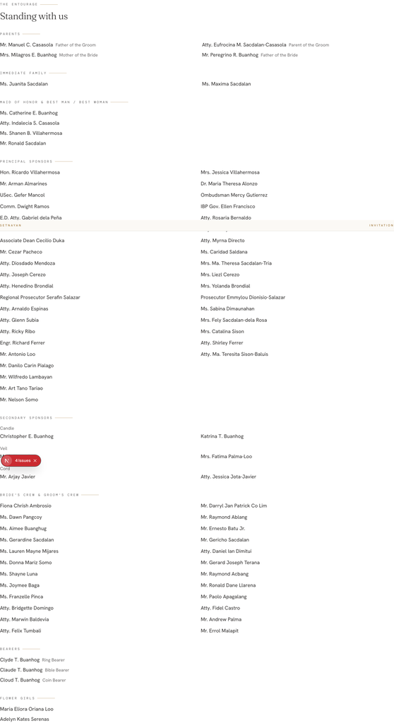

## 2 · shippedTwo sidesreal render

The side is read from the ROLE — as rendered, the bride's side is the LEFT column (Parents of the Bride · Maid of Honor · Ninang · Bridesmaid) and the groom's side the RIGHT (Parents of the Groom · Groom's Family · Best Woman · Best Man · Ninong · Groomsman). What no role places (Candle · Veil · Cord, the bearers, the flower girls) prints once under a rule, centred, as the pairs the couple made. Uneven pairs cost nothing here: 21 Ninongs are simply a longer column than 17 Ninangs — but a Ninong no longer stands beside HIS Ninang.

375 × 812 · Chromium

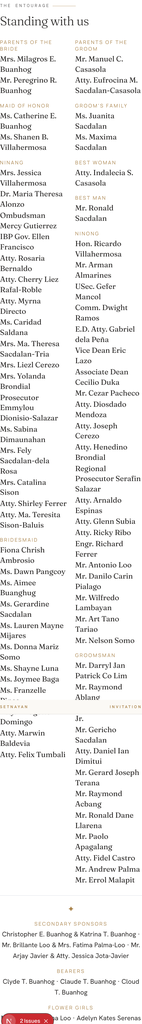

1280 × 800

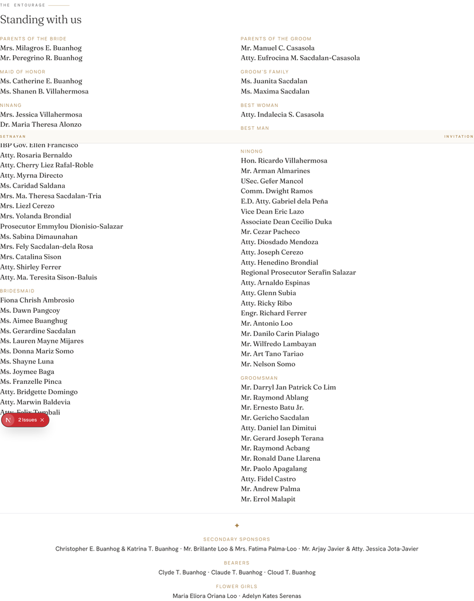

## 3 · shippedThe marchreal render

Numbered, in walking order, each role under its names — the real `march_walks` of this event (48 lines). A pair walks as one line ("Hon. Ricardo Villahermosa & Mrs. Jessica Villahermosa"); a solo Ninong is his own numbered line. A signed-in member sees their own line lifted ("you walk 12th") — the lab has no signed-in guest, so no line is marked here.

375 × 812 · Chromium

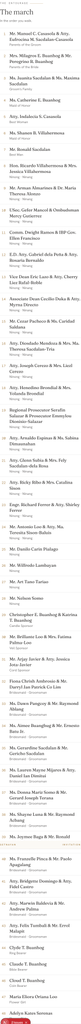

1280 × 800

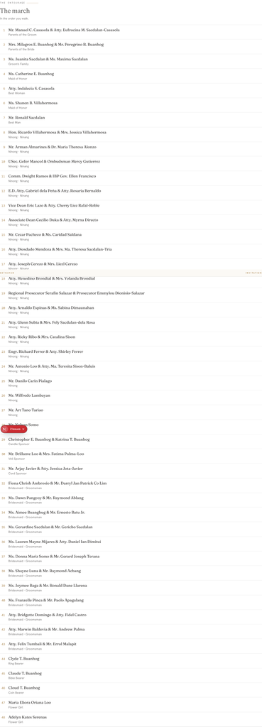

## Keep / drop — one line each, then the recommendation

1

**Keep** — as the plain default. It is the shipped component and the owner's 2026-10-14 ruling drawn; its only crowding left is Parents stacking to one column at 375 with the role beside a long name, which 4 and 5 both fix. If 4 or 5 is picked, 1 is not a second style — it is the same component, cleaned.

2

**Drop** (or keep only for an event with no walking pairs). It breaks exactly the thing this cast has: 17 Ninong–Ninang pairs. In Two sides a Ninong no longer stands beside his Ninang; the reader has to count down two columns to find who walks with whom, and the two Maids of Honor sit opposite one Best Man and one Best Woman as if paired. Its one strength — uneven sides cost nothing — is the march's strength too.

3

**Keep** — it is the Wedding March itself, a different entity (owner 2026-10-01), and the only style that tells a member WHEN they walk ("you walk 12th"). Not the Invitation's default: 48 numbered lines with "&" is the long way to read a list, and the 2026-10-14 "no &" ruling was about the Roll call, not this.

4

**Keep — recommended default for a wedding.** Pairs read as pairs at the centre, uneven pairs stay honest (a blank Ninang cell is a fact, not a gap), a solo keeps his side, long names cannot wreck a row, no role is repeated under 38 sponsors. One component, four small deltas (below).

5

**Keep** as the alternative if the owner would rather scan a flush-left list. It is 4 without the axis plus centred singles — the four solo Ninongs become four centred lines that say "Ninong", which is clear but repeats the word the 2026-09-30 ruling removed, and a centred single sits astride the gutter. Pick 4 OR 5 — both is two spellings of one idea.

**Recommendation:** keep 1 · 3 · 4 (or 5 in 4's place); drop 2. Build 4 as a clean-up of the Roll call, not as a fourth style in `scene-styles-stages.ts` — the owner asked for "a clean way to present the entourage", and a cleaner Roll call is that; a fourth tile would make the couple choose between two near-identical lists.

### Delta to build 4 (files and symbols)

- `apps/web/app/[slug]/_components/entourage-section.tsx` — the unpaired-group branch: `grid-cols-1 … sm:grid-cols-2` → `grid-cols-2` and drop `hidden sm:block` on the blank `Cell` (a blank holds its column at 375); `Cell` + `PairRow`: the `beside` span becomes a block UNDER the name (`block font-sans text-[10px] uppercase tracking-[0.16em] text-gild`) — `roleBesideName` still decides whether, only where changes; `PairRow` left cell `text-right`; the single-person branch keeps its side via `sideOfRole` (already exported from `entourage-styles.tsx`) instead of "starts in the left column"; a tiny `ColumnWords` row for a group with `sideWords`, from the same `roleNameMany`/`roleNameOne` the heading uses, so a renamed role shows the couple's word; `ByRoleGroup`'s "Candle" line takes the same small-caps style, centred; the `h4.pahina-eyebrow` heading wraps in a two-hairline centred divider.
- `apps/web/lib/entourage.ts` — no change to building or order; expose a group's `sideWords` on `EntourageGroup` (one read-only field; today only `groupHeading` consumes them).
- `apps/web/lib/scene-styles-stages.ts` — no new style; the Roll call's `line` copy only. `lib/print-layout.ts` untouched (the card keeps option 1). Two sides and The march untouched.
- Guards: the #6541 guard stays green by construction (two columns at 375, no "&", hidden "and", `min-w-0`); add: no `sm:grid-cols` left in the file; `beside` never inline beside `.name`. Walk Principal Sponsors at 375: "Regional Prosecutor Serafin Salazar" | "Prosecutor Emmylou Dionisio-Salazar" is the widest row — ~153-px cells, 3 | 3 lines, first lines level, no sideways scroll.

### Questions (≤3), with the recommended answer

**Q1 · Is 4 (or 5) a CLEAN-UP of the Roll call, or a fourth style tile beside Roll call · Two sides · The march?**Recommended: a clean-up. Same component, same name; the couple never chooses between two near-identical lists. If the owner wants the old Roll call kept as-is for other events, it costs one more style id (`axis`) and a tile line.

**Q2 · The four solo Ninongs: a row each with the Ninang cell blank (4), or centred lines saying "Ninong" (5)?**Recommended: blank cell (4). It is the 2026-09-14 ruling, says the truth at a glance (21 vs 17), and never repeats a role word under a sponsor. The couple can also pair them in the Wedding March, which removes the question.

**Q3 · Drop Two sides for weddings?**Recommended: yes — withdraw its tile for the wedding type (`eventTypes` in `scene-styles-stages.ts` already limits it to weddings; make it none, or keep it only when the cast has no walking pairs — `entourageHasTwoSides` is already the gate, add "and no pair"). It unpairs exactly what the march paired.

### Where this came from

Read, read-only: `origin/rd/batch-8-event-hub` — `entourage-section.tsx`, `entourage-styles.tsx`, `lib/entourage.ts`, `lib/scene-styles-stages.ts`, the Maker lab (`app/dev/maker-lab/guest`, fed the production export through `buildEntourage`, worktree only, nothing committed); PR #6541; DECISION_LOG 2026-09-14 · 09-20 · 09-30 (×3) · 10-01 · 10-06 · 10-14; `controller-2026-10-12/entourage-cale-ice.json`; prototypes `post_event_scenes_styles_2026-09-29-entourage-375.png`, `wedding_march_drag_maker_2026-10-06_fable.html`, `event_hub_guest_desktop_2026-10-15_fable.html` (Roll call frame). The real renders are Chromium in the lab, not a real iPhone.